# 04

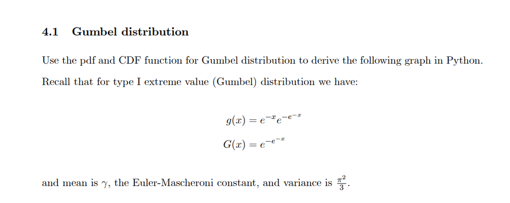

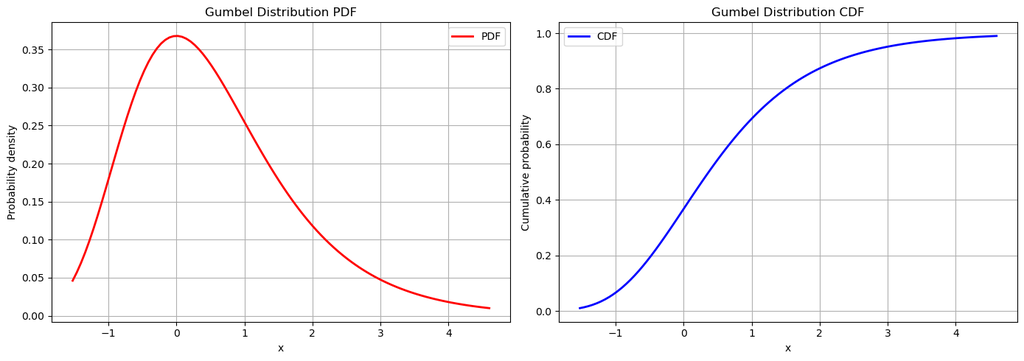

```python
import numpy as np
import matplotlib.pyplot as plt
from scipy.stats import gumbel_r


loc, scale = 0, 1
x = np.linspace(gumbel_r.ppf(0.01, loc, scale), gumbel_r.ppf(0.99, loc, scale), 100)


pdf = gumbel_r.pdf(x, loc, scale)
cdf = gumbel_r.cdf(x, loc, scale)


fig, ax = plt.subplots(1, 2, figsize=(14, 5))


ax[0].plot(x, pdf, 'r-', lw=2, label='PDF')
ax[0].set_title('Gumbel Distribution PDF')
ax[0].set_xlabel('x')
ax[0].set_ylabel('Probability density')
ax[0].legend()
ax[0].grid(True)

ax[1].plot(x, cdf, 'b-', lw=2, label='CDF')
ax[1].set_title('Gumbel Distribution CDF')
ax[1].set_xlabel('x')
ax[1].set_ylabel('Cumulative probability')
ax[1].legend()
ax[1].grid(True)

plt.tight_layout()
plt.show()
```

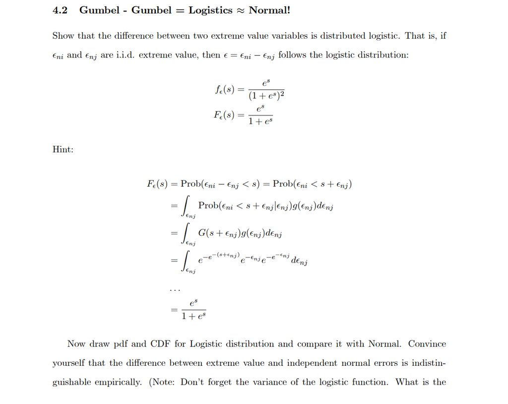

### The function $ F_{\varepsilon}(s)$:

\begin{align*} F_{\varepsilon}(s) &= \text{Prob}(\varepsilon_{ni} - \varepsilon_{nj} \leq s) = \text{Prob}(\varepsilon_{ni} \leq s + \varepsilon_{nj}) \\ &= \int_{\varepsilon_{nj}} \text{Prob}(\varepsilon_{ni} \leq s + \varepsilon_{nj}) g(\varepsilon_{nj}) d\varepsilon_{nj} \\ &= \int_{\varepsilon_{nj}} G(s + \varepsilon_{nj}) g(\varepsilon_{nj}) d\varepsilon_{nj} \\ &= \int e^{-e^{-(s+\varepsilon_{nj})}} e^{-\varepsilon_{nj}} e^{-e^{-\varepsilon_{nj}}} d\varepsilon_{nj} \end{align*}

### Variable transformation:

\begin{align*} e^{{-\varepsilon}_{nj}} &= w \\ -e^{{-\varepsilon}_{nj}}d{\varepsilon}_{nj} &= dw \end{align*}

if ${\varepsilon}_{nj}$ changes from $-\infty$ to $\infty$, w would change from $\infty$ to $0$.

### The function $F_{\varepsilon}(s)$:

\begin{align*} F_{\varepsilon}(s) &= -\int_{\infty}^{0} e^{-we^{-s}} e^{-w} dw \\ &= \left. - \frac{e^{-w(e^{-s}+1)}}{1+e^{-s}}\right|_{0}^{\infty} \\ &= \frac{1}{1+e^{-s}}\\ &=\frac{e^s}{1+e^{s}} \end{align*}

### The derivative of $ F_{\varepsilon}(s)$ is $f_{\varepsilon}(s)$ (probability distribution function of $\varepsilon$):

\begin{align*} \frac{dF_{\varepsilon}(s)}{ds} &= \frac{e^{s}}{(1+e^{s})^2} \end{align*}

$$ Var(X-Y) = Var(X) + Var(Y) = \frac{\pi^2}{6} + \frac{\pi^2}{6} = \frac{\pi^2}{3} $$

Formally, we can write this relationship as:

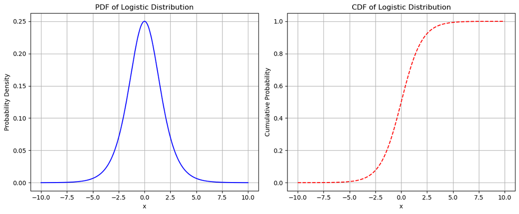

```python
import numpy as np
import matplotlib.pyplot as plt


def logistic_cdf(x, mu=0, s=1):
    return 1 / (1 + np.exp(-(x - mu) / s))
def logistic_pdf(x, mu=0, s=1):
    return np.exp(-(x - mu) / s) / (s * (1 + np.exp(-(x - mu) / s))**2)
# Generate x values
x_values = np.linspace(-10, 10, 400)

# Compute y values using the logistic function
cdf_values = logistic_cdf(x_values)

pdf_values = logistic_pdf(x_values)


fig, axs = plt.subplots(1, 2, figsize=(12, 5))


axs[0].plot(x_values, pdf_values, label='PDF', color='blue')
axs[0].set_title('PDF of Logistic Distribution')
axs[0].set_xlabel('x')
axs[0].set_ylabel('Probability Density')
axs[0].grid(True)


axs[1].plot(x_values, cdf_values, label='CDF', color='red', linestyle='--')
axs[1].set_title('CDF of Logistic Distribution')
axs[1].set_xlabel('x')
axs[1].set_ylabel('Cumulative Probability')
axs[1].grid(True)


plt.tight_layout()
plt.show()
```

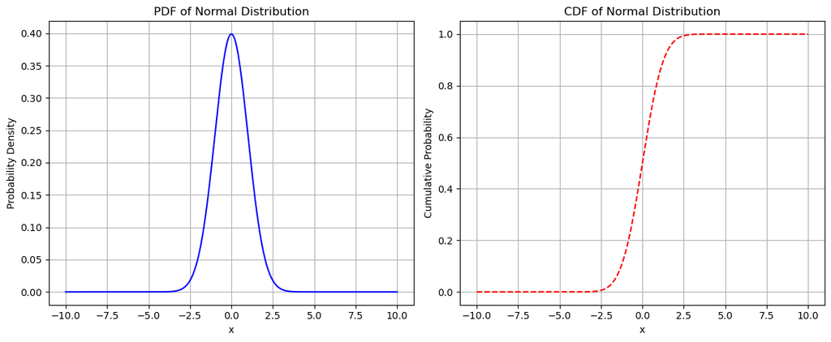

```python
from scipy.stats import norm


x_values = np.linspace(-10, 10, 400)


normal_pdf_values = norm.pdf(x_values, loc=0, scale=1)


normal_cdf_values = norm.cdf(x_values, loc=0, scale=1)


fig, axs = plt.subplots(1, 2, figsize=(12, 5))


axs[0].plot(x_values, normal_pdf_values, label='PDF', color='blue')
axs[0].set_title('PDF of Normal Distribution')
axs[0].set_xlabel('x')
axs[0].set_ylabel('Probability Density')
axs[0].grid(True)


axs[1].plot(x_values, normal_cdf_values, label='CDF', color='red', linestyle='--')
axs[1].set_title('CDF of Normal Distribution')
axs[1].set_xlabel('x')
axs[1].set_ylabel('Cumulative Probability')
axs[1].grid(True)


plt.tight_layout()
plt.show()
```

We are convinced that logistic distribution with the mentioend parameters is very similar to normal distribution with a appropriate sacling!!

### Similarity Between Logistic and Normal Distributions

It can be infered that a Logistic distribution, particularly when chosen with specific parameters, can closely resemble a Normal distribution under an appropriate scaling. This comparison involves understanding the properties of both distributions and how they can be made to appear similar under certain conditions.

#### Logistic Distribution

The Logistic distribution, with location parameter $\mu$ and scale parameter $s$, has a cumulative distribution function (CDF) given by:

$$ F(x) = \frac{1}{1 + e^{-\frac{x - \mu}{s}}} $$

Its probability density function (PDF) is:

$$ f(x) = \frac{e^{-\frac{x - \mu}{s}}}{s\left(1 + e^{-\frac{x - \mu}{s}}\right)^2} $$

The Logistic distribution is characterized by heavier tails compared to the Normal distribution, which allows it to handle outliers more effectively in certain contexts, like logistic regression.

#### Normal Distribution

The Normal distribution, with mean $\mu$ and standard deviation $\sigma$, has a PDF given by:

$$ f(x) = \frac{1}{\sigma\sqrt{2\pi}} e^{-\frac{1}{2}\left(\frac{x - \mu}{\sigma}\right)^2} $$

#### Similarity and Scaling

The key to making a Logistic distribution resemble a Normal distribution lies in appropriate scaling.

The key takeaway is that while the Logistic and Normal distributions have different mathematical formulations and tail behaviors, with careful selection of parameters, the Logistic distribution can be scaled to closely resemble a Normal distribution in terms of its spread and central tendency.

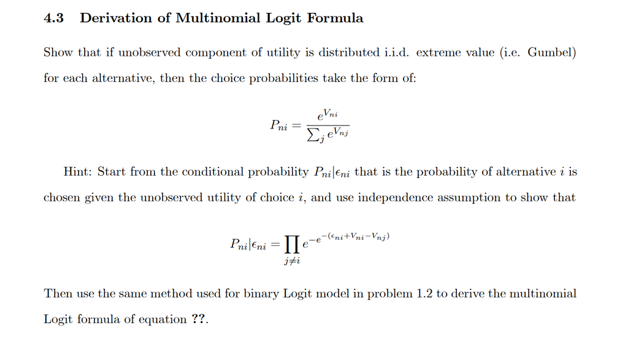

$\varepsilon_{ni}$ is not given, so the choice probability is

$$ P_{ni} = \int \left( \prod_{j \neq i} e^{-e^{-(\varepsilon_{ni}+V_{ni}-V_{nj})}} \right) e^{-\varepsilon_{ni}} e^{-e^{-\varepsilon_{ni}}} d\varepsilon_{ni} $$

if ${\varepsilon}_{nj}$ changes from $-\infty$ to $\infty$, $w$ would change from $\infty$ to $0$.

\begin{align*} P_{ni} &= \int^{\infty}_{0} \prod_{j \neq i} e^{-w\,e^{V_{nj}-V_{ni}}} e^{-w} \, dw \\ &= \int^{\infty}_{0} e^{-w\, \sum_{j \neq i} e^{V_{nj}-V_{ni}}} e^{-w} \, dw \\ &= \int^{\infty}_{0} e^{-w\, \left(\sum_{j \neq i} e^{V_{nj}-V_{ni}} + 1\right)} \, dw \\ &= \int^{\infty}_{0} e^{-w\, \sum_{j} e^{V_{nj}-V_{ni}}} \, dw \\ &= - \left. \frac{e^{-w\, \sum_{j} e^{V_{nj}-V_{ni}}}}{\sum_{j} e^{V_{nj}-V_{ni}}} \right|_{0}^{\infty} \\ &= \frac{1}{\sum_{j} e^{V_{nj}-V_{ni}}} \\ &= \frac{e^{V_{ni}}}{\sum_{j} e^{V_{nj}}} \end{align*}

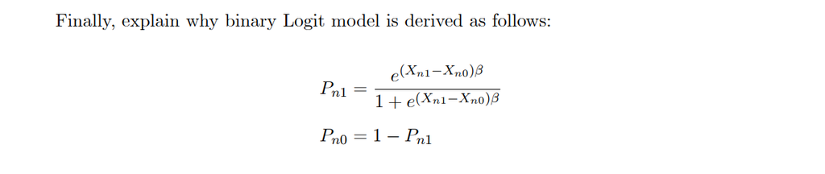

In a binary Logit model for two possible outcomes, the probability of outcome $ i$ occurring over outcome $ j$ (where $j$ is usually the "reference" category) can be expressed as:

$$ \frac{P(Y = i)}{P(Y = j)} = e^{(V_{ni} - V_{nj})} $$

Substituting the linear functions for $ V_{ni}$ and $ V_{nj}$, we get:

$$ \frac{P(Y = i)}{P(Y = j)} = e^{(X_{ni}\beta - X_{nj}\beta)} = e^{(X_{ni} - X_{nj})\beta} $$

For binary outcomes where ( i = 1 ) and ( j = 0 ), the probability of outcome 1 is:

$$ P_{n1} = \frac{e^{(X_{n1} - X_{n0})\beta}}{1 + e^{(X_{n1} - X_{n0})\beta}} $$

This follows the logistic function, where the probability of a particular event occurring is modeled as a function of the exponential of the linear combination of the predictor variables. The denominator normalizes this value to ensure that the probability is between 0 and 1.

The probability of the alternate outcome $0$ is simply:

$$ P_{n0} = 1 - P_{n1} $$

By using the logistic function, the logit model captures the non-linear relationship between the predictor variables and the probability of the outcome. It ensures that the predicted probabilities will fall between 0 and 1, making it a suitable model for binary response variables.

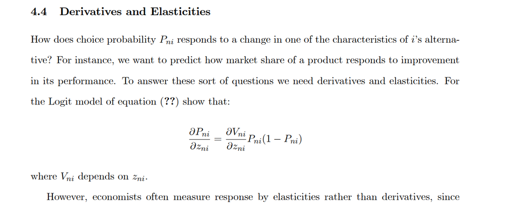

$$ \begin{aligned} P_n &= \frac{e^{V_{n_i}}}{\sum_{j} e^{V_{n_j}}} \\ \frac{\partial P_{n_i}}{\partial Z_{n_i}} &= \frac{e^{V_{n_i}}\left(\sum_{j} e^{V_{n_j}}\right) - \left(e^{V_{n_i}}\right)^2}{\left(\sum_{j} e^{V_{n_j}}\right)^2}\frac{\partial V_{n_i}}{\partial Z_{n_i}} \\ &= P_{n_i} \left(1 - P_{n_i}\right) \frac{\partial V_{n_i}}{\partial Z_{n_i}} \end{aligned} $$

Then

$$ \frac{\partial P_{n_i}}{\partial Z_{n_i}} = P_{n_i} (1 - P_{n_i}) \frac{\partial V_{n_i}}{\partial Z_{n_i}} $$

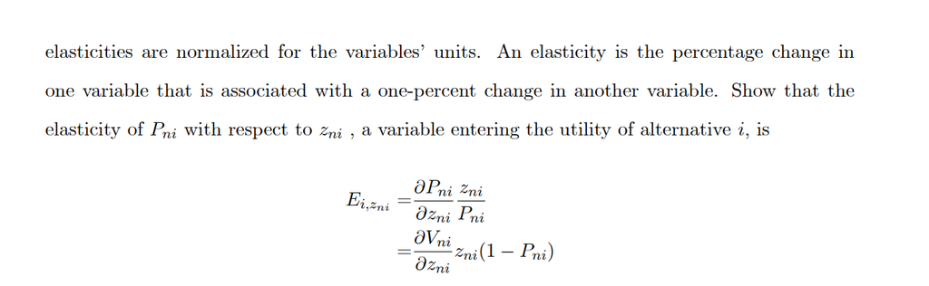

$$ E_{i, Z_{ni}} = P_{n_i} (1 - P_{n_i}) \frac{\partial V_{n_i}}{\partial Z_{n_i}} \frac{z_{ni}}{P_{ni}} $$$$ E_{i, Z_{ni}} = \frac{\partial V_{ni}}{\partial Z_{ni}} z_{ni} (1 - P_{n_i}) $$

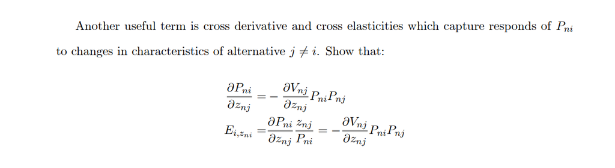

We know that : \begin{equation} P_{n_i}=\dfrac{e^{V_{n_i}}}{\left(\sum_{k}^{}e^{V_{n_k}}\right)} \end{equation} When $j\neq i$ \begin{equation} \dfrac{\partial P_{n_i}}{\partial Z_{n_j}}= -e^{V_{n_i}}\dfrac{e^{V_{n_j}}}{\left(\sum_{k}^{}e^{V_{n_k}}\right)^2} \dfrac{\mathrm{d} V_{n_j}}{\mathrm{d} Z_{n_j}}= - \dfrac{e^{V_{n_i}}}{\sum_{k}^{}e^{V_{n_k}}} \dfrac{e^{V_{n_j}}}{\sum_{k}^{}e^{V_{n_k}}} \dfrac{\partial V_{n_j}}{\partial Z_{n_j}} \end{equation} So what we get is (for $i\neq j $): \begin{equation} \dfrac{\partial P_{n_i}}{\partial Z_{n_j}}=- P_{n_i}P_{n_j} \dfrac{\partial V_{n_j}}{\partial Z_{n_j}} \end{equation} \begin{equation} E_{i, Z_{nj}}= -\frac{\partial V_{nj}}{\partial Z_{nj}} z_{nj} P_{nj} \end{equation}